# Six Frame Translator

**Travis Bingeman**  
**R Wizardry Course, Winter 2017**  
**Lewis Research Group**  
**University of Calgary**

**Background & Use**

Proteogenomics is an approach that lies at the interface of proteomics and genomics and can be used to verify and validate genetic models [1]. It can leverage proteomics data to improve genetic annotation in the genome. The standard approach to identifying peptides and proteins from a sample using mass spectrometry is to compare the tandem mass spectra of the sample to a database of possible protein and peptide sequences. One limitation to this approach is the comprehensiveness of the database. Identifications simply cannot be made if the peptide or protein has not been characterized previously in that database[2]. There is a high reliance on *in silico* annotated proteomes which may contain errors and may be incomplete[2]. In this situation, a proteogenomic approach that relies on a custom genomic database rather than the annotated reference proteome may be necessary to allow novel peptides to map to novel translated regions. One such approach is to employ six frame translation of the genome[2]. While proteomic diversity in eukaryotes is largely a result of alternative mRNA splicing, this approach is more promising in prokaryotes where variables such as exons and introns are less common.

**Details of Six-Frame Translation**  
Genetic information is stored in the genome of an organism as a sequence of nucleotides in either deoxyribonucleic acids or ribonucleic acids (DNA or RNA). Three consecutive nucleotides are translated into an amino acid, and this is called a codon. The amino acid encoded is determined by the sequence of nucleotides in the codon (Figure 1).

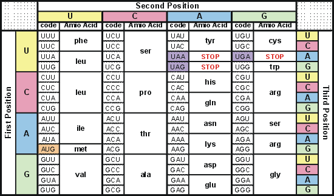

**Figure 1. RNA Codon Table.**  
Depicts nucleotide to amino acid translation based on first, second and third nucleotide identity at each of the three positions in the codon. Credit to http://bioinfo.bisr.res.in/cgi-bin/project/crat/theory_codon_restriction.cgi

Each string of nucleotides has a 5’ end characterized by a phosphoryl group and a 3’ end characterized by a hydroxyl group. A strand of nucleic acids is read in the 5’ -> 3’ direction, the nucleotide position from which the read begins determines the open reading frame. There are 3 possible open reading frames in a single strand of nucleotides (Figure 2). Since DNA is double-stranded by nature, a 5’ -> 3’ strand of DNA will have an implicit antiparallel 3’ -> 5’ complimentary strand. This complimentary strand also has 3 possible open reading frames to interpret from 5’ -> 3’. This gives a total potential 6 frames of translation for a DNA sequence, and 3 frames of translation for a RNA sequence.

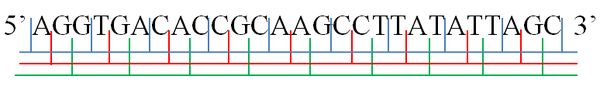

**Figure 2. Reading Frame Illustration**  
Each reading frame is delineated by red, blue and green respectively. The first open reading frame, as outlined by blue has a codon containing “AGG”, followed by “TGA”, etc. The second open reading frame is outlined by red and includes codons with nucleotides “GGT”, “GAC”, “ACC”, etc. Finally, the third open reading frame depicted on this figure as outlined in green is “GTG”, “ACA”, “CCG”, etc. Credit to Hornung Akos. https://en.wikipedia.org/wiki/Reading_frame  
There are a few web-based tools that provide the same functionality as this R solution, but obviously for my purposes having something that I can access within the R environment has a great deal of value. For validation, these resources were helpful. Please see http://web.expasy.org/translate/ and http://www.bioline.com/us/media/calculator/01_13.html for reference.

Package **stringi** was installed and used to speed up some operations. Unfortunately, including this package triggers a warning because it was built with R version 3.2.5 and I am using R version 3.2.1.

```r
#install.packages("stringi")
library("stringi", lib.loc="~/R/win-library/3.2")
```

The **setupCodonList()** function take a string paramater **sStop** that can be over-ridden by the user to specify a symbol that they would like to represent a stop codon otherwise indicated by an asterix. This function initializes two lists. The first list maps nucleotide codons to the single amino acid code, the second list maps nucleotide codons to the 3 letter amino acid code. These two lists are contained by another list. The inner lists serve as lookup tables for decoding the nucleotides into amino acids.

```r
## function to set up relationship between nucleotide codon and amino acid code,
## allows customization of stop codon symbol - serves as programmatic equivalent
## to RNA codon table
setupCodonList <- function(sStop = "*")
{

  # set up lists to map nucleotide codons to amino acid 3 letter or 1 letter abbreviations

  cAA3 <-     c("Phe", "Phe", "Leu", "Leu", "Leu", "Leu", "Leu", "Leu", "Ile", "Ile", "Ile", "Met", "Val",
                "Val", "Val", "Val", "Ser", "Ser", "Ser", "Ser", "Pro", "Pro", "Pro", "Pro", "Thr", "Thr",
                "Thr", "Thr", "Ala", "Ala","Ala", "Ala", "Tyr", "Tyr", "*", "*", "His", "His", "Gln", "Gln",
                "Asn", "Asn", "Lys", "Lys", "Asp", "Asp", "Glu", "Glu", "Cys", "Cys", "*", "Trp", "Arg",
                "Arg", "Arg", "Arg", "Ser", "Ser", "Arg", "Arg", "Gly", "Gly", "Gly", "Gly")

  cAA1 <-     c("F", "F", "L", "L", "L", "L", "L", "L", "I", "I", "I", "M", "V", "V", "V", "V", "S", "S", "S",
                "S","P", "P", "P", "P", "T", "T", "T", "T", "A", "A", "A", "A", "Y", "Y", "*", "*", "H", "H",
                "Q", "Q", "N", "N", "K", "K", "D", "D", "E", "E", "C", "C", "*", "W", "R", "R", "R", "R", "S",
                "S", "R", "R", "G", "G", "G", "G")

  ## check if symbol for stop codon was changed from default
  ## if changed, see if it is identical to one of existing symbols used for an amino acid and
  ## prevent duplication if identical to amino acid symbol, stay with default asterix,
  ## otherwise susbsitute requested symbol

  if (sStop != "*")
  {
    count <- (length(which(cAA3 == sStop)) + length(which(cAA1 == sStop)) )
    if (count == 0) ## symbol not in use, free to use as stop codon symbol
    {
      cAA3[which(cAA3 == "*")] <- sStop
      cAA1[which(cAA1 == "*")] <- sStop
    }
  }

  ## potentential 3 nucleotide codons that encode for amino acids or stop codons
  vCodons <-  c("UUU", "UUC", "UUA", "UUG", "CUU", "CUC", "CUA", "CUG", "AUU", "AUC", "AUA", "AUG", "GUU",
                "GUC", "GUA", "GUG", "UCU", "UCC", "UCA", "UCG", "CCU", "CCC", "CCA", "CCG", "ACU", "ACC",
                "ACA", "ACG", "GCU", "GCC", "GCA", "GCG", "UAU", "UAC", "UAA", "UAG", "CAU", "CAC", "CAA",
                "CAG", "AAU", "AAC", "AAA", "AAG", "GAU", "GAC", "GAA", "GAG", "UGU", "UGC", "UGA", "UGG",
                "CGU", "CGC", "CGA", "CGG", "AGU", "AGC", "AGA", "AGG", "GGU", "GGC", "GGA", "GGG")

  ## pre-allocate memory for lists
  lAA3Code <- vector(mode="list", length = length(vCodons))
  lAA1Code <- vector(mode="list", length = length(vCodons))

  ## name the lists by codon for ease of reference
  names(lAA3Code) <- vCodons
  names(lAA1Code) <- vCodons

  ## initialize each list with 3 letter and 1 letter amino acid code per codon respectively
  for (i in 1: length(lAA3Code))
  {
    lAA3Code[[i]] <- cAA3[[i]]
    lAA1Code[[i]] <- cAA1[[i]]
  }
  ## pre-allocate a 2 member list to contain our 2 member lists
  lAACodes <- vector(mode="list", length = 2)

  ## initialize our container list with the 3 letter and 1 letter amino acid lookup lists
  lAACodes[[1]] <- lAA1Code
  lAACodes[[2]] <- lAA3Code

## return the container list of lookup amino acid codes
return(lAACodes)
}
```